# Identifying Social Media Bot Accounts Through Supervised Machine Learning Classification

William White - WGU D502 Capstone

## Business Understanding

### Problem/Need:

Social media and other modern platforms can have thousands to millions of users at any given time. Of those users, an unknown number of bots could inflate user accounts, affecting ad analytics teams and trust & safety groups. Removing or negating the fraudulent accounts can reduce the load on the system, cut wasteful spending and improve platform integrity.

### Research Question:

Can machine learning models predict whether social media accounts are bot accounts based on account-level features using the TwiBot-20 dataset as measured on a held-out test set?

### Hypothesis:

Bot accounts differ from human accounts in tweets per day, followers/following ratios, and account age, which produce significant differences between the groups.

### Success Criteria:

This project will be considered successful if the following metrics are met on a held-out test set after model selection:

1. Primary: PR-AUC >= ~.65 ; Secondary: ROC-AUC >= ~.70
2. F1-score (test) >= baseline + .15
3. Accuracy > majority class rate
4. Precision at 50% recall (for bots & test) >= Precision baseline (positive bot-class) + .10

### In-Scope:

This capstone will include:

1. the TwiBot-20 dataset
2. Clean/preprocess raw JSON & CSV files, as necessary
3. Engineer account-level features for followers, tweet counts, follower ratios, etc.
4. Train/test/evaluate classification models as previously defined
5. Perform statistical testing (t-test/correlation) for hypothesis support
6. Create visualizations and provide a final, written report
7. Produce public visualizations for interpretation with Tableau and a simple app interface for inputting demo information.

### Out-of-Scope:

This capstone will not include:

1. API calls to retrieve data, such as the public Twitter/X API
2. Any proprietary, private, restricted, or confidential information, Financial estimates, or impacts to actual revenue/costing (e.g., ad revenue estimations, ROI, etc.)
3. Deep learning (e.g., neural networks)

## Data Understanding

### Data Understanding Phase 1: ID Review and Mapping

```python
# import modules
import sys
import platform
import scipy
import json
import math
from datetime import datetime
from pathlib import Path
import sklearn
from sklearn.ensemble import HistGradientBoostingClassifier
from sklearn.linear_model import LogisticRegression
from sklearn.model_selection import StratifiedKFold, cross_val_predict, GridSearchCV
from sklearn.naive_bayes import GaussianNB
from sklearn.metrics import (
    precision_recall_curve, f1_score, precision_score, recall_score, confusion_matrix,
    roc_auc_score, average_precision_score, PrecisionRecallDisplay
)
from sklearn.pipeline import Pipeline
from sklearn.preprocessing import StandardScaler
import numpy as np
import pandas as pd
import matplotlib
import matplotlib.pyplot as plt
import seaborn as sns
from pathlib import Path
```

```python
# path setup
ROOT = Path.cwd().parent
RAW = ROOT / "data" / "raw"
PROCESSED = ROOT / "data" / "processed"
```

```python
# create default helper dataframes and check overall shape/rows
labels_path = RAW / "labels.csv"
df_labels = pd.read_csv(labels_path)

split_path = RAW / "split.csv"
df_split = pd.read_csv(split_path)

edges_path = RAW / "edges.csv"
df_edges = pd.read_csv(edges_path)

print(f"Labels Dataframe Shape: {df_labels.shape}")
print(f"\nSplit Dataframe Shape: {df_split.shape}")
```

```
Labels Dataframe Shape: (11826, 2)

Split Dataframe Shape: (229580, 2)
```

```python
# duplicate check for potential cleaning purposes
print("Number of Unique Bot & Human ID's:")
display(df_labels.nunique())

print("\nNumber of Unique ID's in the Split pool:")
display(df_split.nunique())
```

```
Number of Unique Bot & Human ID's:
```

```
id       11826
label        2
dtype: int64
```

```
Number of Unique ID's in the Split pool:
```

```
id       229580
split         4
dtype: int64
```

```python
# prepare ID map by first ensuring the label & split dataframes have normalized casing and strip whitespace
# if necessary
df_labels_pre = df_labels.copy()
df_split_pre = df_split.copy()

df_labels_pre['id'] = df_labels_pre['id'].str.lower().str.strip()
df_split_pre['id'] = df_split_pre['id'].str.lower().str.strip()

id_map_df = pd.merge(df_labels_pre, df_split_pre, on='id', how='left')

print("ID Map Sample:")
display(id_map_df.head())

print("\nID Map Shape:")
display(id_map_df.shape)

print("\nNumber of Null Values in ID Map:")
display(id_map_df.isnull().sum())

print("\nNumber of unique ID's:")
display(id_map_df.nunique())
```

```
ID Map Sample:
```

|  | id | label | split |
| --- | --- | --- | --- |
| 0 | u17461978 | human | train |
| 1 | u1297437077403885568 | bot | train |
| 2 | u17685258 | human | train |
| 3 | u15750898 | human | train |
| 4 | u1659167666 | bot | train |

```
ID Map Shape:
```

```
(11826, 3)
```

```
Number of Null Values in ID Map:
```

```
id       0
label    0
split    0
dtype: int64
```

```
Number of unique ID's:
```

```
id       11826
label        2
split        3
dtype: int64
```

```python
# count and proportions of labels & split coverage for usable ID's
label_count = id_map_df['label'].value_counts()
split_count = id_map_df['split'].value_counts()

label_summary = label_count.rename('Count').to_frame().assign(Proportion=lambda d: (d['Count']/d['Count'].sum()*100).round(2))
split_summary = split_count.rename('Count').to_frame().assign(Proportion=lambda p: (p['Count']/p['Count'].sum()*100).round(2))

print("Bot vs Human Count/Proportion:")
display(label_summary)

print("\nData Split Type Count/Proportion:")
display(split_summary)
```

```
Bot vs Human Count/Proportion:
```

| label | Count | Proportion |
| --- | --- | --- |
| bot | 6589 | 55.72 |
| human | 5237 | 44.28 |

```
Data Split Type Count/Proportion:
```

| split | Count | Proportion |
| --- | --- | --- |
| train | 8278 | 70.0 |
| val | 2365 | 20.0 |
| test | 1183 | 10.0 |

```python
# determine class balance among splits
train_val_mask = id_map_df['split'].isin(['train', 'val'])
test_mask = id_map_df['split'].eq('test')

train_val_lab_count = id_map_df.loc[train_val_mask, 'label'].value_counts()
test_lab_count = id_map_df.loc[test_mask, 'label'].value_counts()

train_val_lab_summary = train_val_lab_count.rename('Count').to_frame().assign(Proportion=lambda t: (t['Count']/t['Count'].sum()*100).round(2))
test_lab_summary = test_lab_count.rename('Count').to_frame().assign(Proportion=lambda s: (s['Count']/s['Count'].sum()*100).round(2))

print("Training & Validation Data Class Balance:")
display(train_val_lab_summary)

print("\nTest Data Class Balance:")
display(test_lab_summary)
```

```
Training & Validation Data Class Balance:
```

| label | Count | Proportion |
| --- | --- | --- |
| bot | 5949 | 55.9 |
| human | 4694 | 44.1 |

```
Test Data Class Balance:
```

| label | Count | Proportion |
| --- | --- | --- |
| bot | 640 | 54.1 |
| human | 543 | 45.9 |

```python
# lock IDs for each split for any testing later
train_val_id_lock = set(id_map_df.loc[id_map_df['split'].isin(['train','val']), 'id'])
test_id_lock = set(id_map_df.loc[id_map_df['split'].eq('test'), 'id'])

id_map_df.to_csv('../data/processed/id_map.csv', index=False)
pd.Series(sorted(train_val_id_lock), name='id').to_csv('../data/processed/train_val_ids.csv', index=False)
pd.Series(sorted(test_id_lock), name='id').to_csv('../data/processed/test_ids.csv', index=False)
```

### Data Understanding Phase 1 Summary

**Data Integrity Results**:  
All IDs, explicitly taken from the labeled data to ensure results are only based on appropriate bot & human accounts, have been canonicalized to strip any potential white space. All are lowercase, and all IDs were verified as unique in all splits. This also made it simple to ensure there is a disjoint between the training & test sets before locking the IDs in the test, so it is a hold-out test from the beginning.

**Overall Counts and Proportions**:  
The overall training set is 8,278 (70.0%) of the labeled data and was combined with the validation set, 2,365 (20.0%), before being split for this project in a later step, and the test data has 1,183 (10.0%) of the accounts. The TwiBot-20 dataset has zero support labeled Twitter accounts, and we are left with 11,826 accounts to use.

In terms of overall balance, in the training set, bots have 5,949 (55.9%) and human accounts have 4,694 (44.1%) of the identified accounts. This creates our training baselines by identifying bot accounts with an accuracy of at least 55.9% and a PR-AUC baseline of approximately 0.559.

Bots make up 640 (54.1%) in the testing set, while human accounts are set at 543 (45.9%). For testing, we have our majority-account accuracy baseline to beat at 54.1% and a PR-AUC baseline of approximately 0.541.

As stated earlier, the test ID set was separated and locked out to ensure that any associated IDs do not bleed into the training pool. There is a clear imbalance between the classes, with bots making up most of the population, training, and testing. The training and test sets have a similar balance between the accounts, which provides a good starting point for generalization.

**Artifact recording**:  
The id_map_df file, containing the complete set of IDs, their labels, and what split they are a part of, was saved in the data/processed folder, and the ID lists for both splits were created to allow quick reproducibility later.

**Advantage at this stage**:  
The data is:

1. precise,
2. has a well-defined training pool/testing sets partitioned into almost 12,000 labeled accounts, and
3. its set up to support an unbiased evaluation with even group splits throughout.

**Limitations at this stage**:  
There are currently two limitations with the data that have to be taken into account when preparing, exploring, and working with the data:

1. The data is currently in JSON format, but the types are messy (e.g., booleans and dates are objects/strings, there are trailing spaces in multiple fields, etc). These must be prepared and verified when creating the actual, final dataframes.
2. The data file contains more than enough information compared to any other bot detection dataset now, which is almost 7 gigabytes. This leads to slow loading times and will require streaming IDs whenever necessary, as well as saving curated ID files of the IDs used to ensure training and tests are done on time.

### Data Understanding Phase 2: Data Peeks

```python
import ijson
```

```python
# Test stream data.json items from the json dictionary, which is keyed by id, using ijson to map only the items in the training/test sets as needed.
train_sample_info=[]

with open('../data/raw/data.json', 'rb') as file:
    # filter only allowable uid
    for uid, info in ijson.kvitems(file, ""):
        if uid not in train_val_id_lock:
            continue
        # retrieve only necessary fields for analysis if the uid is in the set
        pm = info.get('public_metrics') or {}
        row = {
            'id': uid,
            'followers_count': pm.get('followers_count'),
            'following_count': pm.get('following_count'),
            'tweet_count': pm.get('tweet_count'),
            'listed_count': pm.get('listed_count'),
            'verified': str(info.get('verified', "")).strip() == 'True',
            'protected': str(info.get('protected', "")).strip() == 'True',
            'created_at': (info.get('created_at') or "").strip(),
        }

        train_sample_info.append(row)

        if len(train_sample_info) >= 200:
            break

peeking = pd.DataFrame(train_sample_info)

display(peeking.head())
display(peeking.info())
display(peeking.shape)
```

|  | id | followers_count | following_count | tweet_count | listed_count | verified | protected | created_at |
| --- | --- | --- | --- | --- | --- | --- | --- | --- |
| 0 | u17461978 | 15349596 | 692 | 9798 | 45568 | True | False | Tue Nov 18 10:27:25 +0000 2008 |
| 1 | u1297437077403885568 | 0 | 44 | 0 | 0 | False | False | Sun Aug 23 07:35:11 +0000 2020 |
| 2 | u17685258 | 762839 | 475 | 5518 | 3201 | True | False | Thu Nov 27 18:47:32 +0000 2008 |
| 3 | u15750898 | 327587 | 4801 | 192876 | 1744 | True | False | Wed Aug 06 15:12:10 +0000 2008 |
| 4 | u1659167666 | 13324 | 647 | 103 | 44 | False | False | Sat Aug 10 03:25:35 +0000 2013 |

```
<class 'pandas.core.frame.DataFrame'>
RangeIndex: 200 entries, 0 to 199
Data columns (total 8 columns):
 #   Column           Non-Null Count  Dtype
---  ------           --------------  -----
 0   id               200 non-null    object
 1   followers_count  200 non-null    int64
 2   following_count  200 non-null    int64
 3   tweet_count      200 non-null    int64
 4   listed_count     200 non-null    int64
 5   verified         200 non-null    bool
 6   protected        200 non-null    bool
 7   created_at       200 non-null    object
dtypes: bool(2), int64(4), object(2)
memory usage: 9.9+ KB
```

```
None
```

```
(200, 8)
```

```python
# create full training dataframe following sample success
batch = []
batch_num = 5000
train_csv = Path('../data/processed/training_pool_1.csv')

if train_csv.exists():
    train_csv.unlink()

first_write = True

with open('../data/raw/data.json', 'rb') as file:
    for uid, info in ijson.kvitems(file, ""):
        if uid not in train_val_id_lock:
            continue
        pm = info.get("public_metrics") or {}
        batch.append({
            'id': uid,
            'followers_count': pm.get('followers_count'),
            'following_count': pm.get('following_count'),
            'tweet_count': pm.get('tweet_count'),
            'listed_count': pm.get('listed_count'),
            'verified': str(info.get('verified', "")).strip() == 'True',
            'protected': str(info.get('protected', "")).strip() == 'True',
            'created_at': (info.get('created_at') or "").strip(),
        })

        if len(batch) >= batch_num:
            pd.DataFrame(batch).to_csv(
                train_csv,
                index=False,
                mode=("w" if first_write else "a"),
                header=first_write
            )
            first_write = False
            batch.clear()

if batch:
    pd.DataFrame(batch).to_csv(
        train_csv,
        index=False,
        mode=("w" if first_write else "a"),
        header=first_write
    )

df_training = pd.read_csv(train_csv).drop_duplicates('id', keep='last')
df_training.to_csv(train_csv, index=False)
```

```python
# verify the file was created and works
print(f"Number of Training Pool Shape: {df_training.shape}")
print(f"All Training IDs are Unique: {df_training['id'].is_unique}")
```

```
Number of Training Pool Shape: (10643, 8)
All Training IDs are Unique: True
```

```python
# create full training dataframe following sample success
test_csv = Path('../data/processed/test_pool_1.csv')
test_header = test_csv.exists()

test_list = []

with open('../data/raw/data.json', 'rb') as file:
    for uid, info in ijson.kvitems(file, ""):
        if uid not in test_id_lock:
            continue
        pm = info.get("public_metrics") or {}
        test_list.append({
            'id': uid,
            'followers_count': pm.get('followers_count'),
            'following_count': pm.get('following_count'),
            'tweet_count': pm.get('tweet_count'),
            'listed_count': pm.get('listed_count'),
            'verified': str(info.get('verified', "")).strip() == 'True',
            'protected': str(info.get('protected', "")).strip() == 'True',
            'created_at': (info.get('created_at') or "").strip(),
        })

pd.DataFrame(test_list).to_csv(test_csv, index=False, mode="w", header=True)
```

```python
# verify test file was created
df_test = pd.read_csv(test_csv)
print(f"Number of Test Pool Shape: {df_test.shape}")
print(f"All Test IDs are Unique: {df_test['id'].is_unique}")
```

```
Number of Test Pool Shape: (1183, 8)
All Test IDs are Unique: True
```

```python
display(df_training.info())
display(df_test.info())
```

```
<class 'pandas.core.frame.DataFrame'>
RangeIndex: 10643 entries, 0 to 10642
Data columns (total 8 columns):
 #   Column           Non-Null Count  Dtype
---  ------           --------------  -----
 0   id               10643 non-null  object
 1   followers_count  10643 non-null  int64
 2   following_count  10643 non-null  int64
 3   tweet_count      10643 non-null  int64
 4   listed_count     10643 non-null  int64
 5   verified         10643 non-null  bool
 6   protected        10643 non-null  bool
 7   created_at       10643 non-null  object
dtypes: bool(2), int64(4), object(2)
memory usage: 519.8+ KB
```

```
None
```

```
<class 'pandas.core.frame.DataFrame'>
RangeIndex: 1183 entries, 0 to 1182
Data columns (total 8 columns):
 #   Column           Non-Null Count  Dtype
---  ------           --------------  -----
 0   id               1183 non-null   object
 1   followers_count  1183 non-null   int64
 2   following_count  1183 non-null   int64
 3   tweet_count      1183 non-null   int64
 4   listed_count     1183 non-null   int64
 5   verified         1183 non-null   bool
 6   protected        1183 non-null   bool
 7   created_at       1183 non-null   object
dtypes: bool(2), int64(4), object(2)
memory usage: 57.9+ KB
```

```
None
```

### Data Understanding Phase 2 Summary

The original, raw data file was heavily reduced through streaming only rows with IDs that matched the training pool (for the training file) and the test pool (for the test file). The fields under "public_metrics" in the raw dataset were flattened only to include non-personally identifiable information necessary for analysis. This resulted in the same unique counts, which were previously verified: 10,643 for training and 1,183 for testing, which remain locked from training data.

The columns remaining are:

1. id (row identifier)
2. followers_count (the number of other accounts following the user account)
3. following_count (the number of other accounts the user account is following)
4. tweet_count (the number of tweets sent out)
5. listed_count (the number of public lists, including the user's account, such as public figure tracking)
6. verified (identifies if the account is verified on Twitter)
7. protected (identifies if the account is private, so only approved followers can see tweets)
8. created_at (the date the account was created to denote account age)

The tables were curated to also change the verified & protected fields from their original string objects to booleans. The date field for "created_at" will be parsed in the data preparation phase. The final tables were saved as CSV files to reference and use throughout analysis and review without requiring the entire, original JSON data to be loaded repeatedly.

## Data Preparation

```python
# merge labels into updated dataframes to provide target label
df_training_pre = pd.merge(df_training, id_map_df, on='id', how='left')
df_test_pre = pd.merge(df_test, id_map_df, on='id', how='left')
```

```python
# convert created_at column to datetime
time_format = "%a %b %d %H:%M:%S %z %Y"

for df in [df_training, df_test]:
    df['created_at'] = pd.to_datetime(df['created_at'], format=time_format,errors='coerce', utc=True)

# using the max training date for the reference point of account age
# and to ensure no data leakage into the test data
TRAIN_DATE = df_training['created_at'].max()
TRAIN_DATE_ISO = TRAIN_DATE.isoformat()
```

```python
# convert created_at date into "account_age_days" for modelling
# using the max date in the set subtracted from the user's listed date

#function to create account age number and handle NaN or negatives if
# applicable
def date_age(df, ref_date):
    age = (ref_date - df['created_at']).dt.total_seconds() /  86400.0
    return pd.Series(age).fillna(0).clip(lower=0).round().astype("Int64")

df_training_pre['account_age_days'] = date_age(df_training, TRAIN_DATE)
df_test_pre['account_age_days'] = date_age(df_test, TRAIN_DATE)
```

```python
# create the follower/following ratio calculation and convert to a log
# to account for the extremely heavy skew from famous/public figures with
# very large numbers/outlier ratios; Adding + 1 to both sides to avoid
# dividing by zero and to prevent log explosion if the following count
# is extremely small. With larger accounts, the +1 is effectively no change

for df in (df_training_pre, df_test_pre):
    df['follow_ratio'] = (df['followers_count'] + 1) / (df['following_count'] + 1)
    df['log_follow_ratio'] = np.log1p(df['follow_ratio'])
```

```python
# also turn public_metrics counts into logs to normalize/account for
# public/famous heavy account skews and keep raw columns
METRIC_COLS = ['followers_count', 'following_count', 'tweet_count', 'listed_count']

for df in (df_training_pre, df_test_pre):
    for col in METRIC_COLS:
        df[f"log_{col}"] = np.log1p(df[col])
```

```python
# convert booleans into numeric fields for modeling
for df in (df_training_pre, df_test_pre):
    df['verified_num'] = df['verified'].astype('int64')
    df['protected_num'] = df['protected'].astype('int64')
```

```python
# create final, helpful extra fields for normalizing 'per day' and
# 'per tweet' comparisons. Also applying the same + 1 logic for
# proper division and log explosion protection
for df in (df_training_pre, df_test_pre):
    df['tweets_per_day'] = (df['tweet_count'] + 1) / (df['account_age_days'].replace(0, 1))
    df['followers_per_tweet'] = (df['followers_count'] +1) / (df['tweet_count'] + 1)

    #create logs of new features
    df['log_tweets_per_day'] = np.log1p(df['tweets_per_day'])
    df['log_followers_per_tweet'] = np.log1p(df['followers_per_tweet'])
```

```python
# set up list of engineered features for EDA and modeling analysis
eng_features = [
    'account_age_days',
    'verified_num',
    'protected_num',
    'tweets_per_day',
    'followers_per_tweet',
    'log_tweets_per_day',
    'log_followers_count',
    'log_following_count',
    'log_follow_ratio',
    'log_followers_per_tweet',
    'log_listed_count',
    'log_tweet_count'
]

print(eng_features)
print(len(eng_features), 'features')
```

```
['account_age_days', 'verified_num', 'protected_num', 'tweets_per_day', 'followers_per_tweet', 'log_tweets_per_day', 'log_followers_count', 'log_following_count', 'log_follow_ratio', 'log_followers_per_tweet', 'log_listed_count', 'log_tweet_count']
12 features
```

```python
# save clean data and features list
LABEL = "label"
KEEP = ['id', 'created_at']

training_clean = df_training_pre[KEEP + eng_features + [LABEL]].copy()
test_clean = df_test_pre[KEEP + eng_features + [LABEL]].copy()

meta_info = {
    "reference_date": str(df_training_pre['created_at'].max()),
    "n_features": len(eng_features),
    "training_rows": int(len(training_clean)),
    "test_rows": int(len(test_clean)),
    "class_balancing_training": df_training_pre[LABEL].value_counts().to_dict(),
    "class_balancing_test": df_test_pre[LABEL].value_counts().to_dict(),
}

training_clean_path = '../data/clean/training_clean.csv'
test_clean_path = '../data/clean/test_clean.csv'
features_path = '../data/clean/features.json'
meta_info_path = '../data/clean/meta_info.json'

training_clean.to_csv(training_clean_path, index=False)
test_clean.to_csv(test_clean_path, index=False)
json.dump(eng_features, open(features_path, "w"), indent=2)
json.dump(meta_info, open(meta_info_path, "w"), indent=2)

print("Clean data, features, and meta info written to: ", training_clean_path, test_clean_path, features_path, meta_info_path)
```

```
Clean data, features, and meta info written to:  ../data/clean/training_clean.csv ../data/clean/test_clean.csv ../data/clean/features.json ../data/clean/meta_info.json
```

### Data Preparation Summary

Python and Pandas have been used to prepare the data for analysis and modeling because of their flexibility and ability to scale with JSON and CSV structures, allowing for efficient preprocessing and feature engineering.

The following updates and manipulations were either required or recommended for easier comparisons later in the process:

1. The 'created_at' column in the training pool and test sets was converted into a datetime field. The created_at column will be excluded from training/testing, as the model requires numeric features. Still, the max created_at date of the training working set was used to calculate the age of the account into a specific number that can be used for analysis and comparison. The max training date was used to ensure feature engineering avoids data leakage in the testing data, since we want to ask "how old is the account as of the time of training" and not consider potentially newer accounts during testing that training never saw.
2. All datatypes between the training pool and testing sets were normalized and consistent (e.g., all boolean fields are truly boolean, date fields are dates, etc).
3. Non-predictive identifiers and/or non-numeric features (e.g., 'id', 'split', 'followers_count', 'verified') were excluded from the final feature set to prevent data leakage and to allow the models to run without errors or inconsistency.
4. As I've already mentioned, there are no duplicate IDs in the splits and no overlapping between training and test IDs.

**Feature Engineering**:  
-*account_age_days*: The days between the max training created_at date and each account's specific created_at date to provide a numeric measure of how long the account has existed since training -*follow_ratio*/*log_follow_ratio*: The ratio of followers to following for each account, and the log transformation version. This captures the follower/following balance and avoids dividing by zero errors.

- *log_followers_count*/*log_following_count*/*log_tweet_count*/*log_listed_count*: The natural log of multiple count variables used to reduce the distributions of heavily-tailed features.
- *verified_num*/*protected_num*: Conversion of booleans to numeric fields to ensure numeric encoding is used for all features
- *tweets_per_day*/*followers_per_tweet*/*log_tweets_per_day*/*log_followers_per_tweet*: Normalized ratios for additional comparison features which measure the account's posting behavior relative to the age of the account and the followers it has.

**Final Feature Selection**:  
The final features selected for analysis, after removing redundant and non-numeric features from the raw data (e.g., followers_count, following_count, created_at, id, etc.), are the following 12 features:

1. account_age_days
2. log_follow_ratio
3. log_followers_count
4. log_following_count
5. log_tweet_count
6. log_listed_count
7. verified_num
8. protected_num
9. tweets_per_day
10. followers_per_tweet
11. log_tweets_per_day
12. log_followers_per_tweet

**Governance/Ethics/Privacy**:  
The final datasets contain only the public Twitter account metadata and aggregated fields, with no personally identifiable information, so ethical and privacy concerns should be minimized. All data is stored locally and in a private GitHub repository for security and analysis.

**Training & Test Preparation**:  
To prepare for training and testing in the following stages, the labels from id_map_df were merged into the training and test working dataframes with a left join on the id field. This results in the split information assigning records to the training set (10,643 items) and test set (1,183). The schema was verified between both lists with the same column features and indices; there are no missing or duplicate items or labels, and the datatypes are balanced.

The clean sets were saved in the data/clean folder as "training_clean_csv" and "test_clean_csv" along with the features.json file for tracking and meta_info.json to save the overall information and references used before running analysis and methodology.

## Exploratory Data Analysis Check After Data Prep

```python
# providing a snapshot of the clean datasets following cleaning and preparation in previous stages
print("Clean Training Set Columns/Info:\n")
display(training_clean.info())

print("\nVerification of Training Set Null Count:\n")
display(training_clean.isna().sum())
```

```
Clean Training Set Columns/Info:

<class 'pandas.core.frame.DataFrame'>
RangeIndex: 10643 entries, 0 to 10642
Data columns (total 15 columns):
 #   Column                   Non-Null Count  Dtype
---  ------                   --------------  -----
 0   id                       10643 non-null  object
 1   created_at               10643 non-null  object
 2   account_age_days         10643 non-null  Int64
 3   verified_num             10643 non-null  int64
 4   protected_num            10643 non-null  int64
 5   tweets_per_day           10643 non-null  Float64
 6   followers_per_tweet      10643 non-null  float64
 7   log_tweets_per_day       10643 non-null  Float64
 8   log_followers_count      10643 non-null  float64
 9   log_following_count      10643 non-null  float64
 10  log_follow_ratio         10643 non-null  float64
 11  log_followers_per_tweet  10643 non-null  float64
 12  log_listed_count         10643 non-null  float64
 13  log_tweet_count          10643 non-null  float64
 14  label                    10643 non-null  object
dtypes: Float64(2), Int64(1), float64(7), int64(2), object(3)
memory usage: 1.2+ MB
```

```
None
```

```
Verification of Training Set Null Count:
```

```
id                         0
created_at                 0
account_age_days           0
verified_num               0
protected_num              0
tweets_per_day             0
followers_per_tweet        0
log_tweets_per_day         0
log_followers_count        0
log_following_count        0
log_follow_ratio           0
log_followers_per_tweet    0
log_listed_count           0
log_tweet_count            0
label                      0
dtype: int64
```

```python
# summarize stats info to identify any odd or different ranges that could affect modeling
descriptions = training_clean[eng_features].describe(percentiles=[.01, .05, .25, .5, .75, .95, .99]).T
descriptions = descriptions.rename(columns={'1%':'p01','5%':'p05','25%':'p25','50%':'p50','75%':'p75','95%':'p95','99%':'p99'})

shape = pd.DataFrame({
    'skew': training_clean[eng_features].skew(numeric_only=True),
    'kurt': training_clean[eng_features].kurt(numeric_only=True)
})

profile = (
    descriptions[['count', 'mean', 'std', 'min', 'p01', 'p25', 'p50', 'p75', 'p99', 'max']].join(shape).round(3)
)

profile
```

|  | count | mean | std | min | p01 | p25 | p50 | p75 | p99 | max | skew | kurt |
| --- | --- | --- | --- | --- | --- | --- | --- | --- | --- | --- | --- | --- |
| account_age_days | 10643.0 | 2586.287701 | 1422.432725 | 0.0 | 12.0 | 1345.0 | 2894.0 | 3878.0 | 4777.32 | 5280.0 | -0.391 | -1.164 |
| verified_num | 10643.0 | 0.247862 | 0.431792 | 0.0 | 0.0 | 0.0 | 0.0 | 0.0 | 1.0 | 1.0 | 1.168 | -0.636 |
| protected_num | 10643.0 | 0.000188 | 0.013708 | 0.0 | 0.0 | 0.0 | 0.0 | 0.0 | 0.0 | 1.0 | 72.938 | 5318.999 |
| tweets_per_day | 10643.0 | 8.36521 | 27.385861 | 0.000286 | 0.002191 | 0.294118 | 1.593852 | 6.248175 | 101.047807 | 1296.676589 | 17.113 | 573.373 |
| followers_per_tweet | 10643.0 | 242.598398 | 7162.069511 | 0.000379 | 0.010699 | 0.201562 | 0.91384 | 5.864326 | 3381.402004 | 568209.0 | 68.295 | 4951.641 |
| log_tweets_per_day | 10643.0 | 1.271595 | 1.183106 | 0.000286 | 0.002189 | 0.257829 | 0.953144 | 1.98075 | 4.625441 | 7.168331 | 1.02 | 0.505 |
| log_followers_count | 10643.0 | 7.962561 | 3.725786 | 0.0 | 0.693147 | 5.31812 | 7.58121 | 10.528409 | 16.502692 | 18.618107 | 0.267 | -0.464 |
| log_following_count | 10643.0 | 6.536279 | 1.92092 | 0.0 | 0.693147 | 5.46806 | 6.588926 | 7.661762 | 11.575615 | 15.283381 | -0.158 | 1.462 |
| log_follow_ratio | 10643.0 | 2.323874 | 3.059879 | 0.00155 | 0.015566 | 0.300346 | 0.72736 | 3.512362 | 12.291794 | 18.281784 | 1.664 | 2.134 |
| log_followers_per_tweet | 10643.0 | 1.432693 | 1.853359 | 0.000379 | 0.010643 | 0.183622 | 0.649112 | 1.926338 | 8.126341 | 13.250246 | 1.943 | 3.711 |
| log_listed_count | 10643.0 | 3.262007 | 2.988309 | 0.0 | 0.0 | 0.0 | 2.639057 | 5.568345 | 10.224798 | 13.218004 | 0.584 | -0.768 |
| log_tweet_count | 10643.0 | 7.657098 | 2.774364 | 0.0 | 0.693147 | 6.002651 | 8.176673 | 9.667227 | 12.538894 | 15.452569 | -0.64 | -0.109 |

```python
# setup for plotting
sns.set_theme(style='whitegrid', context='notebook')
```

```python
training_prop = training_clean['label'].value_counts(normalize=True).round(3)
test_prop = test_clean['label'].value_counts(normalize=True).round(3)
pd.DataFrame({'train': training_prop, 'test': test_prop})
```

| label | train | test |
| --- | --- | --- |
| bot | 0.559 | 0.541 |
| human | 0.441 | 0.459 |

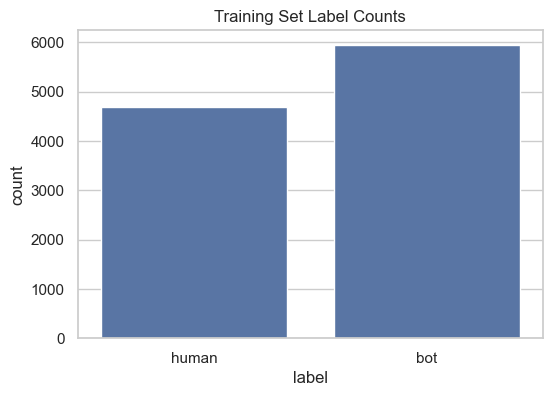

```python
# visualization of label balance for the training set
plt.figure(figsize=(6,4))
label_count = sns.countplot(data=training_clean, x="label")
label_count.set_title("Training Set Label Counts")
```

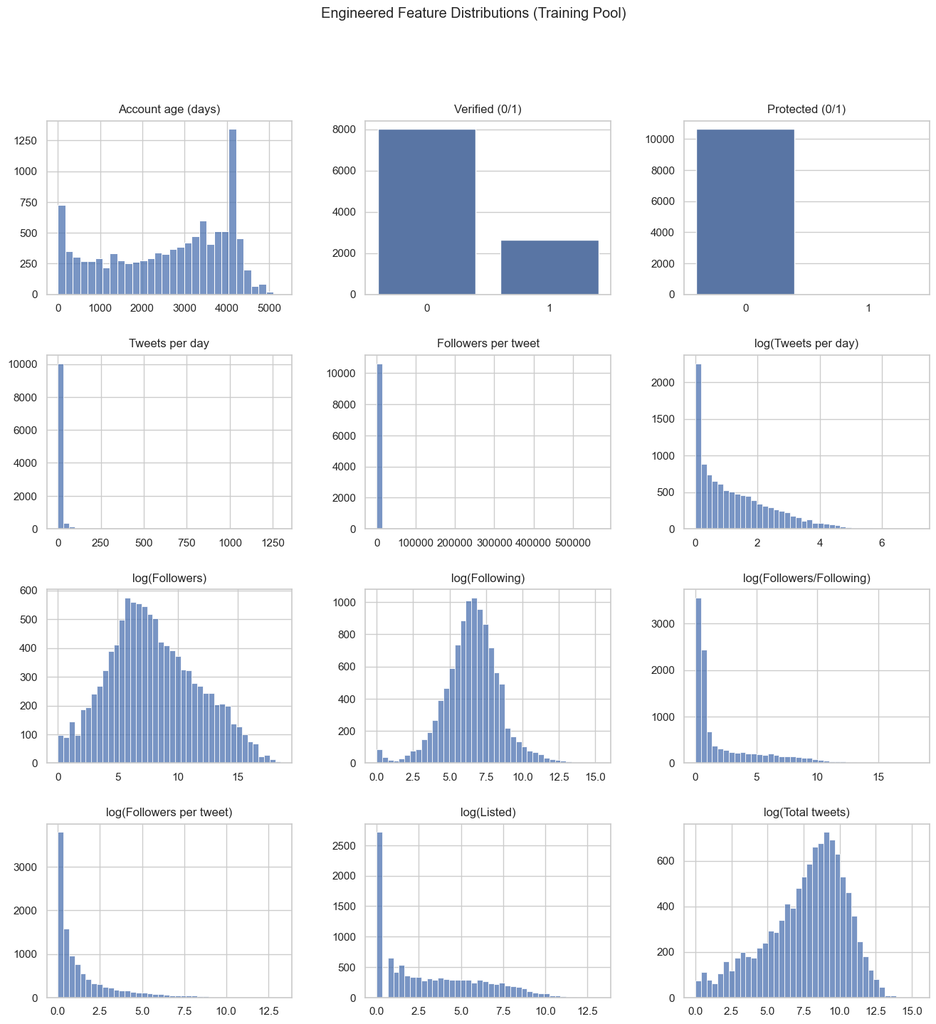

```python
# histogram plots for engineered features to view distributions before modeling
cols = 3
rows = math.ceil(len(eng_features) / cols)

name_map = {
    'account_age_days': 'Account age (days)',
    'verified_num': 'Verified (0/1)',
    'protected_num': 'Protected (0/1)',
    'tweets_per_day': 'Tweets per day',
    'followers_per_tweet': 'Followers per tweet',
    'log_tweets_per_day': 'log(Tweets per day)',
    'log_follow_ratio': 'log(Followers/Following)',
    'log_followers_count': 'log(Followers)',
    'log_following_count': 'log(Following)',
    'log_listed_count': 'log(Listed)',
    'log_tweet_count': 'log(Total tweets)',
    'log_followers_per_tweet': 'log(Followers per tweet)',
}

plot_features = [f for f in eng_features if f in eng_features]
fig, axes = plt.subplots(rows, cols, figsize=(16, 4*rows))
plt.subplots_adjust(hspace=.35, wspace=.3)
axes = axes.ravel()

for ax, f in zip(axes, plot_features):
    if f in ('verified_num','protected_num'):
        sns.countplot(data=training_clean, x=f, ax=ax)
        ax.set_xlim(-0.5, 1.5)
    else:
        # slightly more bins for smoother log features
        bins = 40 if f.startswith('log_') or f.endswith('_per_tweet') or f.endswith('_per_day') else 30
        sns.histplot(data=training_clean, x=f, bins=bins, ax=ax)
    ax.set_title(name_map.get(f, f), fontsize=12, pad=8)
    ax.set_xlabel(None); ax.set_ylabel(None);

fig.suptitle("Engineered Feature Distributions (Training Pool)")
```

```python
# review outliers to check how many rows are beyond the 1st and 99th percentiles before modeling
# so if about 1% or less in the tail, no winsorization required.

non_binary_features = [
    'account_age_days','log_follow_ratio','log_followers_count','log_following_count',
    'log_tweet_count','log_listed_count','tweets_per_day','followers_per_tweet',
    'log_tweets_per_day','log_followers_per_tweet'
]

num = len(training_clean)

p = training_clean[non_binary_features].quantile([.01, .99]).T
p.columns = ['p01', 'p99']

high_count = (training_clean[non_binary_features] > p['p99']).sum().rename('top_99')
low_count = (training_clean[non_binary_features] < p['p01']).sum().rename('bot_01')

outliers = (
    pd.concat([p, high_count, low_count], axis=1)
      .assign(top_percent=lambda d: d['top_99']/num,
              bot_percent=lambda d: d['bot_01']/num)
      .sort_values('top_99', ascending=False)
)

outliers
```

|  | p01 | p99 | top_99 | bot_01 | top_percent | bot_percent |
| --- | --- | --- | --- | --- | --- | --- |
| account_age_days | 12.0 | 4777.32 | 107 | 99 | 0.010054 | 0.009302 |
| log_follow_ratio | 0.015566 | 12.291794 | 107 | 107 | 0.010054 | 0.010054 |
| log_followers_count | 0.693147 | 16.502692 | 107 | 97 | 0.010054 | 0.009114 |
| log_following_count | 0.693147 | 11.575615 | 107 | 87 | 0.010054 | 0.008174 |
| log_tweet_count | 0.693147 | 12.538894 | 107 | 75 | 0.010054 | 0.007047 |
| log_listed_count | 0.0 | 10.224798 | 107 | 0 | 0.010054 | 0.0 |
| tweets_per_day | 0.002191 | 101.047807 | 107 | 107 | 0.010054 | 0.010054 |
| followers_per_tweet | 0.010699 | 3381.402004 | 107 | 107 | 0.010054 | 0.010054 |
| log_tweets_per_day | 0.002189 | 4.625441 | 107 | 107 | 0.010054 | 0.010054 |
| log_followers_per_tweet | 0.010643 | 8.126341 | 107 | 107 | 0.010054 | 0.010054 |

|  | feature | r_pointbiserial | p_mwu | median_bot | median_human |
| --- | --- | --- | --- | --- | --- |
| 7 | log_following_count | 0.087099 | 1.100998e-23 | 6.727432 | 6.421622 |
| 2 | protected_num | -0.001628 | 8.667353e-01 | 0.000000 | 0.000000 |
| 3 | tweets_per_day | -0.017791 | 1.514690e-55 | 1.089811 | 2.458502 |
| 4 | followers_per_tweet | -0.035409 | 0.000000e+00 | 0.466667 | 3.333333 |
| 5 | log_tweets_per_day | -0.115510 | 1.514690e-55 | 0.737074 | 1.240835 |
| 11 | log_tweet_count | -0.179759 | 1.948256e-96 | 7.585281 | 8.781402 |
| 0 | account_age_days | -0.208226 | 3.384031e-112 | 2442.000000 | 3382.000000 |
| 9 | log_followers_per_tweet | -0.398423 | 0.000000e+00 | 0.382992 | 1.466337 |
| 6 | log_followers_count | -0.419774 | 0.000000e+00 | 6.579251 | 10.191200 |
| 10 | log_listed_count | -0.444125 | 0.000000e+00 | 1.609438 | 5.347108 |

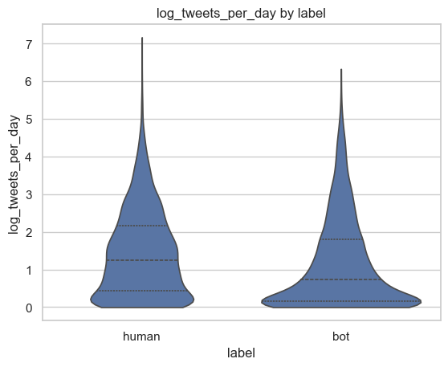

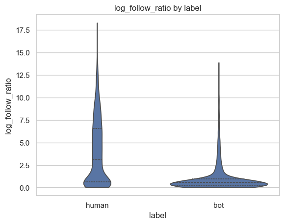

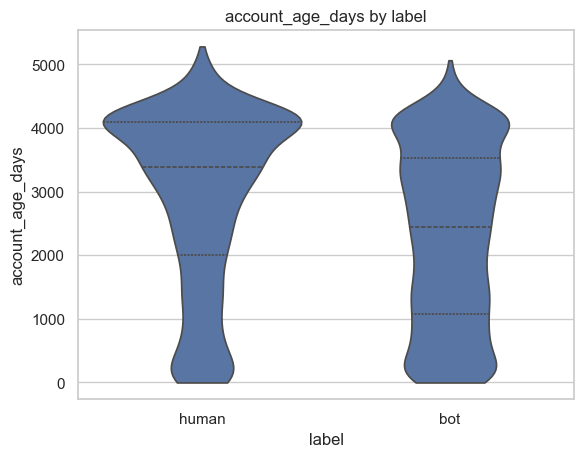

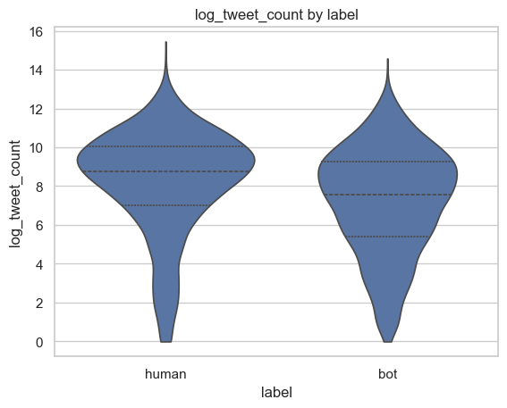

```python
# feature vs label checks for potential correlations before modeling
from scipy.stats import mannwhitneyu, pointbiserialr, ks_2samp

feature_check = ['log_tweets_per_day', 'log_follow_ratio', 'account_age_days', 'log_tweet_count']

for f in feature_check:
    plt.figure()
    sns.violinplot(data=training_clean, x="label", y=f, inner="quartile", cut=0)
    plt.title(f"{f} by label")

rows = []
y_bins = (training_clean['label'] == "bot").astype(int)
for f in eng_features:
    a = training_clean.loc[y_bins == 1, f].dropna()
    b = training_clean.loc[y_bins == 0, f].dropna()
    u, p = mannwhitneyu(a, b, alternative="two-sided")
    r = pointbiserialr(y_bins, training_clean[f]).statistic
    rows.append((f, r, p, float(a.median()), float(b.median())))

feature_signal = pd.DataFrame(rows, columns=['feature', 'r_pointbiserial', 'p_mwu', 'median_bot', 'median_human']).sort_values('r_pointbiserial', ascending=False)
feature_signal.head(10)
```

|  | level_0 | level_1 | r | abs |
| --- | --- | --- | --- | --- |
| 54 | log_followers_count | log_listed_count | 0.894632 | 0.894632 |

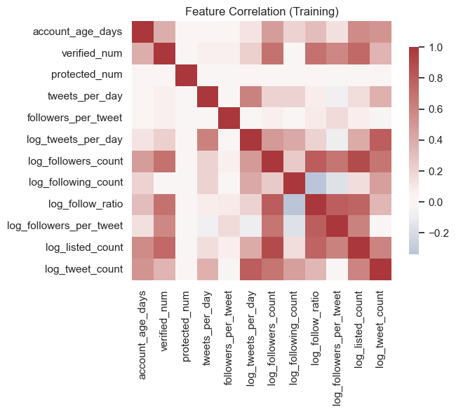

```python
# another pre-check for feature-to-feature correlations to highlight possible linear wobbling
corr = training_clean[eng_features].corr(numeric_only=True)

plt.figure()
sns.heatmap(corr, cmap="vlag", center=0, square=True, cbar_kws={"shrink": .8})

plt.title("Feature Correlation (Training)")

pairs = (
    corr.where(np.triu(np.ones_like(corr, dtype=bool), k=1))
        .stack().rename("r").reset_index()
    .assign(abs=lambda d: d["r"].abs())
    .query("abs >= .85")
    .sort_values("abs", ascending=False)
)

pairs.head(10)
```

```python
# compare train and test feature distribution to check for shifting features/drft
pd.DataFrame({
    'train': training_clean['label'].value_counts(normalize=True).round(3),
    'test' :  test_clean['label'].value_counts(normalize=True).round(3)
})
```

| label | train | test |
| --- | --- | --- |
| bot | 0.559 | 0.541 |
| human | 0.441 | 0.459 |

```python
rows2 = []
for f in eng_features:
    D, p = ks_2samp(training_clean[f], test_clean[f])
    rows2.append((f, D, p, training_clean[f].median(), test_clean[f].median()))

drift = (pd.DataFrame(rows2, columns=["feature", "KS_D", "p", "train_median", "test_median"])).sort_values("KS_D", ascending=False)
drift.head(10)
```

|  | feature | KS_D | p | train_median | test_median |
| --- | --- | --- | --- | --- | --- |
| 11 | log_tweet_count | 0.040015 | 0.064271 | 8.176673 | 8.306966 |
| 6 | log_followers_count | 0.036762 | 0.109653 | 7.581210 | 7.853605 |
| 10 | log_listed_count | 0.034429 | 0.156424 | 2.639057 | 2.890372 |
| 4 | followers_per_tweet | 0.029811 | 0.294399 | 0.913840 | 1.000000 |
| 9 | log_followers_per_tweet | 0.029811 | 0.294399 | 0.649112 | 0.693147 |
| 8 | log_follow_ratio | 0.029733 | 0.297307 | 0.727360 | 0.765210 |
| 1 | verified_num | 0.027708 | 0.380009 | 0.000000 | 0.000000 |
| 0 | account_age_days | 0.023351 | 0.598488 | 2894.000000 | 2930.000000 |
| 5 | log_tweets_per_day | 0.021218 | 0.715435 | 0.953144 | 0.991536 |
| 3 | tweets_per_day | 0.021218 | 0.715435 | 1.593852 | 1.695372 |

```python
# ensure clean modeling matrix and assert excluded columns are not in the feature set
no_inclusion = {'id', 'created_at', 'label', 'split'}
assert no_inclusion.isdisjoint(eng_features)

# split clean assurances
assert not training_clean['id'].duplicated().any()
assert not test_clean['id'].duplicated().any()
assert set(training_clean['id']).isdisjoint(set(test_clean['id']))

# ensure no missing values in features
assert training_clean[eng_features].isna().sum().sum() == 0
assert test_clean[eng_features].isna().sum().sum() == 0

# ensure failure if KS has drift at a = .01
alpha = .01
negative = drift.loc[drift['p'] < alpha, "feature"].tolist()
assert len(negative) == 0, f"Possible drift: {negative} (p < {alpha})"
```

### EDA Summary

Before modeling, the cleaned datasets were reviewed for potential class balance issues, feature behavior, relationships to/between the label targets, and drift/leakage/collinearity risks. Through initial, fundamental analysis and visualization, I was able to observe the following:

1. The training set consists of approximately 10,600+ records with numeric features engineered for training (e.g., age and ratio-based logging) and a binary label for evaluation. Null values are zero across every field as found with .info() and isna() checks.
2. The training data was reviewed using describe() to get the overall profile of the numeric features. The raw data, as thought, has heavy tails when shown throughout the table (e.g., followers_per_tweet average is greater than the median, skew and kurtosis are very high, etc.). The log transformations, however, are more usable. When used in linear modeling, the logs for tweets_per_day and followers_per_tweet have much lower skew and kurtosis. The log-scale counts were reduced to a mild/moderate skew and more logical ranges. Account age is still usable and spans from new to much older accounts, with .01 being around 12 days and .99 being around 4,777 days. The average for verified accounts is around 25% while 'protected' accounts are effectively zero and most likely unnecessary.
3. As previously indicated, a moderate class imbalance was also visualized through a count plot for clear visual interpretation. I will use class weighting and/or tuning to deal with imbalances during modeling and avoid altering the dataset.
4. Histograms were used for all engineered features to provide visualization of the raw counts (confirming an expectation of right-skew on raw data) and the log transformations (showing, overall, much tighter shaping). This validates the transformed features to help support linear modeling.

In addition to the initial, basic data reviews, I also looked at signals and correlation using more advanced plotting and analysis:

1. Violin plotting was used to find the strongest separation from visibility (e.g., tweets and followers) and account age. It was found that bots tend to have fewer followers, are on fewer lists, and have lower follower_per_tweet while also being younger on average. The posting features show weak central tendency differences but have heavier upper tails for some subsets.
2. Count-based features were looked at for clustering as well. The biggest pair, log_followers_count and log_listed_count (with an r around .89), will need to have the redundancy mitigated for linear modeling through regularization and, if necessary, drop one of any pairs that are >= .85. For the gradient boosting, all features will be kept.
3. KS testing was used to compare the training and test compatibility. The testing showed no material drift across the features, with the max D being around .04, and medians were very close. The evaluation should be fair.
4. Outliers were checked with .01 and .99 probability thresholds. Around 1% of the items fall into each tail, per feature, as expected. No winsorization was applied; if necessary, extremes will be clipped for linear modeling.
5. Lastly, the data was checked for leakage and split integrity. IDs, dates, and labels are excluded from the feature sets, and the training & testing IDs are disjoint. The features are all numeric for modeling, with no null or infinity values. Time-based features (i.e., account_age_days) use the max reference date from the training account created_at as previously discussed.

The engineered feature set is well put together and provides excellent information with minimal drift and clear label signals. Logistic regression and gradient-boosted tree modeling should be set up well to move forward and evaluate with CV, F1-score, PR-AUC, and threshold tuning.

## Modeling Approach Plan

### Objective and Primary Metric

This project centers on a binary classification (social media bot account vs human account). The primary objective is to get a maximized F1-score, which balances precision and recall. I will also provide reporting on Precision Recall-Area Under Curve (PR-AUC) and Receiver Operating Characteristic-Area Under Curve (ROC-AUC) to check for completeness. The final decision threshold will be tuned on cross-validated predictions to maximize F1-score, as opposed to a more arbitrary .5 probability in this specific project, and then hold it fixed for the testing evaluation.

While this project uses the TwiBot-20 dataset and follows the dataset's listed split, I have pooled 'train' and 'val' labeled items for cross-validation and model/threshold selection as the training pool. I will hold out the test split to complete a final evaluation.

### Features and Preprocessing

The final dataset for modeling contains only the following engineered and numeric features:

- account_age_days,
- log_follow_ratio,
- log_followers_count,
- log_following_count,
- log_tweet_count,
- log_listed_count,
- tweets_per_day,
- followers_per_tweet,
- log_tweets_per_day,
- log_followers_per_tweet,
- verified_num,
- protected_num

The identifier and time-based fields (id, created_at, label) are excluded to prevent leakage. Counts and heavy-tailed ratios have already been transformed to log versions and booleans to 0/1. There are no missing values, and, for the linear models, features will be standardized through z-score inside the cross-validation folds.

### Models

Three models are being used for training and comparison:

1. Gaussian Naive Bayes (GNB) - This will serve as a fast and simple baseline appropriate for continuous features, further improved by the log transformations, with no scaling required and minimal hyperparameters. This helps to establish the floor for performance.
2. Regularized Logistic Regression (LR) - This will be the interpretable linear classification with L2 regularization and balanced class weight for the previously seen class imbalance. The features will be standardized as needed, and because some count features are highly correlated, as found during the EDA process, I will either drop one of the features from the pair or use regularization.
3. Gradient-Boosted Trees - This non-linear ensemble is being used to capture interactions while handling the correlated inputs well. No scaling is required, and I will use shallow trees, with minimal leaf sizes, L2 shrinkage, and early stopping for regularization.

### Validation Protocol

I will use a 5-fold cross-validation on the training set. The model will fit 4/5 of the data items on each fold, and probability predictions will be made for the last items held out. When put together, these become the out-of-fold (OOF) probabilities for every training record. I will then choose whichever threshold maximizes F1-score on the OOF predictions per model. I will then refit the model for all the training data, use the threshold for the test probabilities once, and report the test metrics. This will separate the model and threshold selection from the final evaluation to prevent test peeking.

### Hyperparameters

I will be using defaults and light tuning as follows:

1. GNB will have no tuning necessary
2. Logistic Regression: L2 penalty, C equal to .1, 1, and 10, a max iteration >= 2000 and balanced class weight.
3. Gradient Boosting will use learning_rate equal to .03 and .1, max_depth equal to 3 to 6, min_samples_leaf equal to 20 to 100, l2_regularization equal to 0 and 1 and early_stopping equal to true.

### Class Balance and Thresholding

I will address imbalances with class weight for Logistical regression and, for all models used, with tuning the operating threshold on the OOF predictions for F1-score optimization. I will also report on precision and recall along with the F1-score to highlight the trade-offs.

### Reproducibility

All experimentation will use fixed, random seeds, and the environment is recorded through an environment.yml and a version stamp at the end of the report. Cross-validation and threshold selection are done inside the training data only, with test results reported once.

# Modeling

### Working Datasets Setup

```python
df_training_working = training_clean.copy()
df_test_working = test_clean.copy()

label_map = {'human': 0, 'bot': 1}
df_training_working['label_num'] = df_training_working['label'].map(label_map)
df_test_working['label_num'] = df_test_working['label'].map(label_map)

X_train = df_training_working[eng_features].copy()
y_train = df_training_working['label_num'].copy()
X_test = df_test_working[eng_features].copy()
y_test = df_test_working['label_num'].copy()

# verify updates to modeling sets are complete
print("X_train: ", X_train.shape, " | X_test: ", X_test.shape)
print("y_train Count:\n", y_train.value_counts())
print("y_test Count: \n", y_test.value_counts())
```

```
X_train:  (10643, 12)  | X_test:  (1183, 12)
y_train Count:
 label_num
1    5949
0    4694
Name: count, dtype: int64
y_test Count:
 label_num
1    640
0    543
Name: count, dtype: int64
```

### Gaussian Naive Bayes

```python
# initialize the model
cv = StratifiedKFold(n_splits=5, shuffle=True, random_state=42)
gnb = GaussianNB()
```

```python
# OOF probabilities for each training row
oof_gnb = cross_val_predict(
    gnb, X_train, y_train, cv=cv, method="predict_proba"
)[:, 1]

cv_roc = roc_auc_score(y_train, oof_gnb)
cv_pr = average_precision_score(y_train, oof_gnb)
print(f"GNB (OOF) - ROC-AUC: {cv_roc:.3f} | PR-AUC: {cv_pr:.3f}")
```

```
GNB (OOF) - ROC-AUC: 0.761 | PR-AUC: 0.712
```

```python
# determine optimal F1-score probability threshold and set CV classification metrics
prec, rec, thresh = precision_recall_curve(y_train, oof_gnb)
f1 = np.divide(2 * prec * rec, (prec + rec), out=np.zeros_like(prec), where=(prec + rec)!=0)

best_idx = int(np.argmax(f1[1:]))
best_thresh = float(thresh[best_idx])
yhat_oof = (oof_gnb >= best_thresh).astype(int)

cv_f1 = f1_score(y_train, yhat_oof)
cv_p = precision_score(y_train, yhat_oof)
cv_r = recall_score(y_train, yhat_oof)
cm = confusion_matrix(y_train, yhat_oof)

print(f"Best threshold: {best_thresh:.3f}")
print(f"OOF threshold -> F1 = {cv_f1:.3f}. Precision = {cv_p:.3f}, Recall = {cv_r:.3f}")
print("OOF Confusion Matrix [[TN FP], [FN TP]]:\n", cm)
```

```
Best threshold: 0.435
OOF threshold -> F1 = 0.837. Precision = 0.744, Recall = 0.956
OOF Confusion Matrix [[TN FP], [FN TP]]:
 [[2743 1951]
 [ 264 5685]]
```

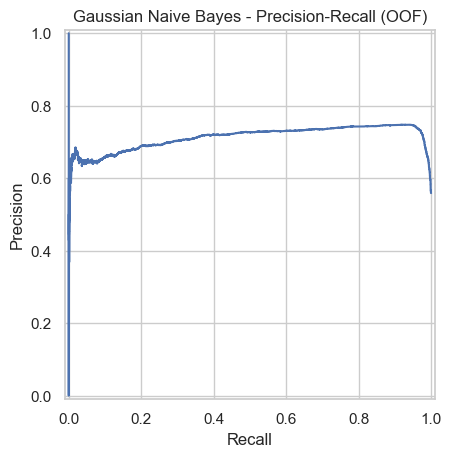

```python
# visualization of GNB training results
PrecisionRecallDisplay(precision=prec, recall=rec).plot()
plt.title("Gaussian Naive Bayes - Precision-Recall (OOF)")
```

#### GNB Training Results

Using a stratified 5-fold cross-validation, GNB computed the following out-of-fold probabilities:

1. ROC-AUC = .761. This means that 76% of the time, the model will rank the bot higher if we randomly pick one bot and one human.
2. PR-AUC = .712. Considering a 'dumb' model would have a PR-AUC of 56% (the proportion of bots in the training set), 71% precision across thresholds on the positive class predictions (bots) means precision stays higher as recall increases.
3. From the out-of-fold PR-AUC I got an F1-optimal threhold of .435. With that threshold, F1 = .837, Precision = .744, and Recall = .956. This model, overall, is extremely aggressive at finding bot accounts with a recall of almost 96%, but provides a tradeoff that it had many false alarms with a precision of a little over 74%.

The baseline for GNB is a very good start, but I will look at logistic regression and gradient-boosting to increase precision without sacrificing too much of the recall score.

### Regularized Logistic Regression

```python
# define linear features
logr_features = [f for f in [
    'account_age_days',
    'log_follow_ratio',
    'log_followers_count',
    'log_following_count',
    'log_tweet_count',
    'tweets_per_day',
    'followers_per_tweet',
    'log_tweets_per_day',
    'log_followers_per_tweet',
    'verified_num',
    'protected_num'
] if f in X_train.columns]

X_train_logr = X_train[logr_features].copy()
X_test_logr = X_test[logr_features].copy()
print("Logistic Regression Feature Count: ", len(logr_features), logr_features)
```

```
Logistic Regression Feature Count:  11 ['account_age_days', 'log_follow_ratio', 'log_followers_count', 'log_following_count', 'log_tweet_count', 'tweets_per_day', 'followers_per_tweet', 'log_tweets_per_day', 'log_followers_per_tweet', 'verified_num', 'protected_num']
```

```python
# prepare C regularization determination and PR-AUC mean
logr_pipe = Pipeline([
    ("scaler", StandardScaler()),
    ("clf", LogisticRegression(
        penalty="l2",
        class_weight="balanced",
        max_iter=5000,
        random_state=42,
        solver="lbfgs"
    ))
])

param_grid = {"clf__C": [.03, .1,.3, 1, 3, 10]}
grid_logr = GridSearchCV(
    logr_pipe, param_grid,
    scoring = "average_precision",
    cv=cv, n_jobs=-1
)

grid_logr.fit(X_train_logr, y_train)
best_logr = grid_logr.best_estimator_
print("Best C: ", grid_logr.best_params_["clf__C"], "| CV (mean) PR-AUC: ", round(grid_logr.best_score_, 3))
```

```
Best C:  10 | CV (mean) PR-AUC:  0.804
```

```python
# coefficient review of standardized features
best_logr.fit(X_train_logr, y_train)
coeff = pd.Series(best_logr.named_steps['clf'].coef_.ravel(), index=logr_features)

human10 = coeff[coeff < 0].sort_values().head(10)
bot10 = coeff[coeff > 0].sort_values(ascending=False).head(10)

print("Top Negative (human):")
display(human10)
print("\nTop Positive (bot):")
display(bot10)
```

```
Top Negative (human):
```

```
verified_num              -3.961807
log_followers_per_tweet   -0.464629
log_tweets_per_day        -0.231871
log_tweet_count           -0.141228
log_follow_ratio          -0.053244
dtype: float64
```

```
Top Positive (bot):
```

```
log_followers_count    0.460725
tweets_per_day         0.183585
log_following_count    0.182644
followers_per_tweet    0.086005
protected_num          0.049108
account_age_days       0.023187
dtype: float64
```

```python
# precision based test with precision threshold set at .8 to determine outcome of fewer false alarms
oof_logr = cross_val_predict(best_logr, X_train_logr, y_train, cv=cv, method="predict_proba")[:, 1]

cv_roc = roc_auc_score(y_train, oof_logr)
cv_pr = average_precision_score(y_train, oof_logr)
print(f"Logistic Regression (OOF) - ROC-AUC: {cv_roc:.3f} | PR-AUC: {cv_pr:.3f}")

prec, rec, thresh = precision_recall_curve(y_train, oof_logr)

targetp = .80
mask = prec[:-1] >= targetp

if mask.any():
    thresh_p80 = float(thresh[mask][0])
    yhat_p80 = (oof_logr >= thresh_p80).astype(int)
    f1_p = f1_score(y_train, yhat_p80)
    p_p  = precision_score(y_train, yhat_p80)
    r_p  = recall_score(y_train, yhat_p80)
    cm_p = confusion_matrix(y_train, yhat_p80)

    print(f"≥{targetp:.0%} Precision Threshold = {thresh_p80:.3f}  →  F1={f1_p:.3f}  P={p_p:.3f}  R={r_p:.3f}")
    print("OOF Confusion Matrix (Precision Target) [[TN FP],[FN TP]]:\n", cm_p)
else:
    print(f"Could not reach precision ≥ {targetp:.0%} anywhere on the OOF PR curve.")
```

```
Logistic Regression (OOF) - ROC-AUC: 0.822 | PR-AUC: 0.803
≥80% Precision Threshold = 0.712  →  F1=0.618  P=0.800  R=0.504
OOF Confusion Matrix (Precision Target) [[TN FP],[FN TP]]:
 [[3945  749]
 [2953 2996]]
```

```python
# recall based test with recall threshold set at .9 to determine outcome of fewer missed bots
def recall_floor(y_true, score, prec, rec, thresh, targetR = .9):
    mask = rec[:-1] >= targetR
    if not mask.any():
        return None

    i = np.argmax(prec[:-1][mask])
    t = float(thresh[mask][i])
    yhat = (score >= t).astype(int)
    return {
        "targetR": targetR,
        "threshold": t,
        "precision": float(precision_score(y_true, yhat)),
        "recall": float(recall_score(y_true, yhat)),
        "f1": float(f1_score(y_true, yhat)),
        "cm": confusion_matrix(y_true, yhat),
        "positives_rate": float(yhat.mean())
    }

res_r90 = recall_floor(y_train, oof_logr, prec, rec, thresh, targetR=0.90)
res_r95 = recall_floor(y_train, oof_logr, prec, rec, thresh, targetR=0.95)

def show_result(tag, result):
    if result is None:
        print(f"{tag}: No threshold meets the recall floor.")
    else:
        print(f"{tag}: Threshold = {result['threshold']:.3f} | Precision = {result['precision']:.3f} Recall = {result['recall']:.3f} "
            f"F1 = {result['f1']:.3f} Flag rate = {result['positives_rate']:.3f}")
        print("Confusion Matrix [[TN FP], [FN TP]]:\n", result['cm'])

show_result("Recall >= 90%: ", res_r90)
show_result("Recall >= 95%: ", res_r95)
```

```
Recall >= 90%: : Threshold = 0.615 | Precision = 0.755 Recall = 0.902 F1 = 0.822 Flag rate = 0.667
Confusion Matrix [[TN FP], [FN TP]]:
 [[2955 1739]
 [ 585 5364]]
Recall >= 95%: : Threshold = 0.581 | Precision = 0.749 Recall = 0.950 F1 = 0.838 Flag rate = 0.709
Confusion Matrix [[TN FP], [FN TP]]:
 [[2800 1894]
 [ 297 5652]]
```

```python
# F1 optimized regression to review higher recall outcomes
f1 = np.divide(2 * prec * rec, (prec + rec), out=np.zeros_like(prec), where=(prec + rec)!=0)
best_idx = int(np.argmax(f1[1:]))
best_thresh_logr = float(thresh[best_idx])

yhat_oof = (oof_logr >= best_thresh_logr).astype(int)
cv_f1 = f1_score(y_train, yhat_oof)
cv_p = precision_score(y_train, yhat_oof)
cv_r = recall_score(y_train, yhat_oof)
cm = confusion_matrix(y_train, yhat_oof)

print(f"Logistic Regression (OOF) threshold = {best_thresh_logr:.3f} - F1 = {cv_f1:.3f} Precision = {cv_p:.3f} Recall = {cv_r:.3f}")
print("OOF Confusion Matrix [[TN FP], [FN TP]]:]\n", cm)
```

```
Logistic Regression (OOF) threshold = 0.014 - F1 = 0.852 Precision = 0.743 Recall = 1.000
OOF Confusion Matrix [[TN FP], [FN TP]]:]
 [[2634 2060]
 [   1 5948]]
```

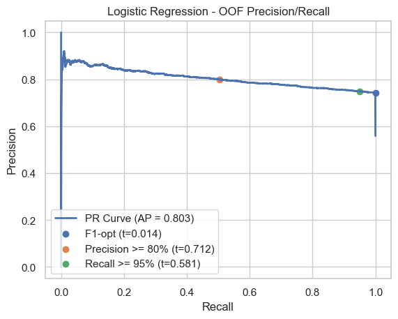

```python
# visualization of Regression modeling results
prec, rec, thresh = precision_recall_curve(y_train, oof_logr)
avg_p = average_precision_score(y_train, oof_logr)

f1 = np.divide(2 * prec * rec, (prec + rec), out=np.zeros_like(prec), where=(prec + rec)!=0)
i_f1 = int(np.argmax(f1[1:]))
t_f1 = float(thresh[i_f1])
p_f1 = prec[i_f1]
r_f1 = rec[i_f1]

mask_p80 = prec[:-1] >= 0.80
p_p80 = prec[:-1][mask_p80][0]
r_p80 = rec[:-1][mask_p80][0]
t_p80 = float(thresh[mask_p80][0]) if mask_p80.any() else (np.nan, np.nan, np.nan)

mask_r95 = rec[:-1] >= 0.95
i_r95 = np.argmax(prec[:-1][mask_r95]) if mask_r95.any() else None
p_r95 = prec[:-1][mask_r95][i_r95]
r_r95 = rec[:-1][mask_r95][i_r95]
t_r95 = float(thresh[mask_r95][i_r95]) if mask_r95.any() else (np.nan, np.nan, np.nan)

figure, ax = plt.subplots()
ax.step(rec, prec, where="post", linewidth=2, label=f"PR Curve (AP = {avg_p:.3f})")
sns.scatterplot(x=[r_f1], y=[p_f1], s=60, ax=ax, label=f"F1-opt (t={t_f1:.3f})")
sns.scatterplot(x=[r_p80], y=[p_p80], s=60, ax=ax, label=f"Precision >= 80% (t={t_p80:.3f})")
sns.scatterplot(x=[r_r95], y=[p_r95], s=60, ax=ax, label=f"Recall >= 95% (t={t_r95:.3f})")

ax.set_xlabel("Recall")
ax.set_ylabel("Precision")
ax.set_title("Logistic Regression - OOF Precision/Recall")
ax.legend(loc="lower left")
```

#### Logistic Regression Results

To model the data using Logistic Regression (setup as L2 regularized, scaled, and class-weighted), 11 numeric features were engineered:

- 'account_age_days',
- 'log_follow_ratio',
- 'log_followers_count',
- 'log_following_count',
- 'log_tweet_count',
- 'tweets_per_day',
- 'followers_per_tweet',
- 'log_tweets_per_day',
- 'log_followers_per_tweet',
- 'verified_num',
- 'protected_num'

As identified in the EDA stage, log_listed_count was found to be highly collinear with log_followers_count (approximately 88 to .9), so log_listed_count was dropped to improve stability.

To tune the model, I used a 5-fold stratified cross-validation method with a grid over C equal to .03, .1, .3, 1, 3, and 10. PR-AUC was used to score and a C of 10 was recorded as the best regularization for L2, so the penalty on coefficients was mild.

Threshold-free (OOF) ranking: ROC-AUC of .822 and PR-AUC of 803, both of which are well above the random baseline that is approximately the bot rate.

To find the best possible regression model for testing, I ran three policies against the same tuned Logistic Regression model to test differing thresholds:

1. **Precision >=.8**: The first was a precision policy to find potential improvements over the PR-AUC Naive Bayes baseline of .712. Precision was set to .8, a fairly sizeable increase with a reduction in false alarms, and that precision was achieved while trying to maximize recall. Unfortunately, the maximum recall it achieved to get an .8 precision rate was a recall of.504. This dropped from the Naive baseline (.956) of over .45.
2. **Recall >= .9/.95**: The following test attempted to increase precision while maintaining a recall of at least .90. Recall at .95 was also tested to see if precision could be improved while maintaining that baseline recall. Recall was kept at .95, with a precision of .749 (an increase from the Naive baseline by .005), which was far better than reducing the recall by .05 and getting a precision increase of only .007. Overall, a reasonably good increase and catching 95% of bot accounts.
3. **F1-Optimized**: The final training model used was an F1 optimization policy. The optimal F1-score was found with a threshold of .014. It resulted in a precision score of .743, effectively the same precision as the Naive baseline, but a recall increase 1.0 and the highest F1 score of .852 to balance precision and recall. This means it could identify virtually 100% of the bot accounts with almost no loss in precision.

The precision model was very clean, but missed half of the bots, which would not meet the goals of this project. The recall weighted model performed slightly better in precision (by .006) but at a loss of 5% of the bot accounts, again a good outcome, but not hitting the project's primary goal.

In summary, the F1-optimized model is the current choice to move toward validation testing as it delivered the highest F1-score by boosting recall to approximately 1.0 with almost no precision loss. The final determination will depend on gradient-boost training.

### Gradient Boosting

```python
# HGB model creation
hgb = HistGradientBoostingClassifier(
    learning_rate = .05,
    max_depth = 4,
    min_samples_leaf = 50,
    l2_regularization = .1,
    early_stopping = True,
    validation_fraction = .1,
    n_iter_no_change = 30,
    max_iter = 1000,
    random_state = 42
)

X_train_hgb = training_clean[eng_features].copy()
X_test_hgb = test_clean[eng_features].copy()

print("Shapes: ", X_train_hgb.shape, X_test_hgb.shape)
print("Features: ", list(X_train_hgb.columns))
```

```
Shapes:  (10643, 12) (1183, 12)
Features:  ['account_age_days', 'verified_num', 'protected_num', 'tweets_per_day', 'followers_per_tweet', 'log_tweets_per_day', 'log_followers_count', 'log_following_count', 'log_follow_ratio', 'log_followers_per_tweet', 'log_listed_count', 'log_tweet_count']
```

```python
# determine ROC-AUC and PR-AUC scoring
cv = StratifiedKFold(n_splits=5, shuffle=True, random_state=42)

oof_hgb = cross_val_predict(hgb, X_train_hgb, y_train, cv=cv, method="predict_proba")[:,1]

hgb_roc = roc_auc_score(y_train, oof_hgb)
hgb_avg_p = average_precision_score(y_train, oof_hgb)
print(f"HGB OOF - ROC-AUC: {hgb_roc:.3f} | PR-AUC {hgb_avg_p:.3f}")
```

```
HGB OOF - ROC-AUC: 0.843 | PR-AUC 0.828
```

```python
# determine HGB recall F1/precision/recall for comparison
prec, rec, thresh = precision_recall_curve(y_train, oof_hgb)

f1 = np.divide(2 * prec * rec, (prec + rec), out=np.zeros_like(prec), where=(prec + rec)!=0)
i_f1 = int(np.argmax(f1[1:]))
t_f1 = float(thresh[i_f1])
p_f1 = float(prec[i_f1])
r_f1 = float(rec[i_f1])
f1_f1 = float(f1[i_f1])
print("HGB - F1-opt: ", dict(thresh = t_f1, p = p_f1, r = r_f1, f1 = f1_f1))

mask = rec[:-1] >= .95
if mask.any():
    j = np.argmax(prec[:-1][mask])
    t_r95 = float(thresh[mask][j])
    p_r95 = float(prec[:-1][mask][j])
    r_r95 = float(rec[:-1][mask][j])
    f1_r95 = float(2 * p_r95 * r_r95/(p_r95 + r_r95))
    print("HGB - Recall >= 95%: ", dict(thresh = t_r95, p = p_r95, r = r_r95, f1 = f1_r95))
else:
    print("HGB - Recall >= 95%: Not Achievable on OOF Curve")
```

```
HGB - F1-opt:  {'thresh': 0.47415682525879044, 'p': 0.7527831094049904, 'r': 0.988905698436712, 'f1': 0.8548387096774194}
HGB - Recall >= 95%:  {'thresh': 0.57995139146946, 'p': 0.7640221651574537, 'r': 0.9502437384434359, 'f1': 0.8470182798921188}
```

```python
# lock in the F1 and 95% thresholds
t_f1_hgb = float(thresh[i_f1])
t_r95_hgb = float(thresh[mask][j])

t_f1_hgb, t_r95_hgb
```

```
(0.47415682525879044, 0.57995139146946)
```

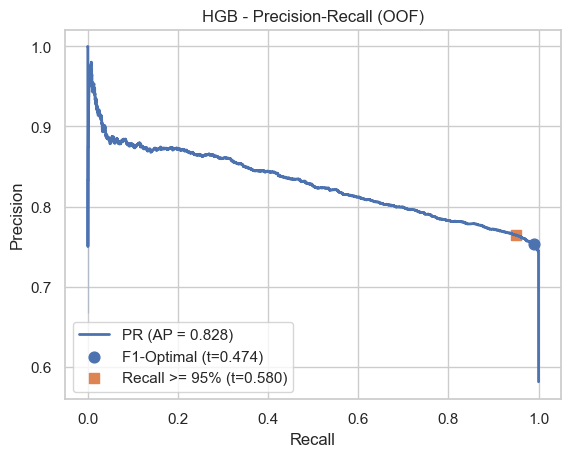

```python
# visualizations for HGB results
has_r95 = bool(mask.any())

plt.figure()
sns.lineplot(x=rec, y=prec, drawstyle="steps-post", linewidth=2, label=f"PR (AP = {hgb_avg_p:.3f})")
plt.scatter([r_f1], [p_f1], s=60, label=f"F1-Optimal (t={t_f1:.3f})")
if has_r95:
    plt.scatter([r_r95],[p_r95], s=60, marker="s", label=f"Recall >= 95% (t={t_r95:.3f})")
plt.xlabel("Recall")
plt.ylabel("Precision")
plt.title("HGB - Precision-Recall (OOF)")
plt.legend(loc='lower left')
```

#### Gradient Boosting Results

HistGradientBoosting (HGB) was used for gradient boosting training on feature value histograms, and its speed and regularization were good. It handled the numeric features well, is robust for the skew/outliers seen previously, and required no scaling.

All 12 engineered features were used for this training as trees require no scaling. Like the logistic regression, cross-validation was done with a 5-fold Stratified K-fold to produce the out-of-fold probabilities without leakage. The model hyperparameters used were:

- learning_rate=0.05,
- max_depth=4,
- min_samples_leaf=50,
- l2_regularization=0.1,
- early_stopping=True,
- validation_fraction=0.1,
- n_iter_no_change=30,
- max_iter=1000,
- random_state=42

The overall metrics found through training for HGB were:

- ROC-AUC: 0843
- PR-AUC: .828
- F1-Optimal: Threshold = .474, Precision = .753, Recall = .989, F1 = .855
- Recall >= 95%: Threshold = .580, Precision = .764, Recall = .950, F1 = .847

To compare:

1. Gaussian Naive Bayes (OOF) a. ROC-AUC: .761 b. PR-AUC: .712 c. F1-Optimal: Precision = .744, Recall = .956, F1 = .837
2. Logistic Regression a. ROC-AUC: .822 b. PR-AUC: .803 c. F1-Optimal: Threshold = .014, Precision = .743, Recall = 1.000, F1 = .852 d. Recall >= 95%: Threshold = .581, Precision = .749, Recall = .950, F1 = .838

With these final training comparisons, the following recommendation is made: HistGradientBoosting with F1-Optimal policy should be used. It improved the PR-AUC, F1, and Precision over Logistic Regression and Naive Bayes with almost no tradeoff to recall. A near-perfect .989 Recall ensures we capture nearly all bots and a respectable .753 precision to avoid as much manual review work and false alarms as possible. The precision-recall trade-off for bot detection is the best match found in training.

The exact, unrounded threshold for the HGB OOF F1-Optimal computations is being locked in for use.

## Evaluation

```python
# build the HGB test model with the same parameters
hgb_final = HistGradientBoostingClassifier(
    learning_rate = .05,
    max_depth = 4,
    min_samples_leaf = 50,
    l2_regularization = .1,
    early_stopping = True,
    validation_fraction = .1,
    n_iter_no_change = 30,
    max_iter = 1000,
    random_state = 42
)

hgb_final.fit(X_train_hgb, y_train)

prob_test = hgb_final.predict_proba(X_test_hgb)[:, 1]

test_roc = roc_auc_score(y_test, prob_test)
test_avg_p = average_precision_score(y_test, prob_test)
print(f"Test - ROC-AUC: {test_roc:.3f} | PR-AUC: {test_avg_p:.3f}")

thresh = t_f1_hgb
yhat = (prob_test >= thresh).astype(int)

p = precision_score(y_test, yhat, zero_division=0)
r = recall_score(y_test, yhat, zero_division=0)
f1 = f1_score(y_test, yhat, zero_division=0)
cm = confusion_matrix(y_test, yhat)
flag_rate = yhat.mean()
prevalence = y_test.mean()

print(f"Test - locked threshold = {thresh:.6f}: Precision = {p:.3f} Recall = {r:.3f} F1 = {f1:.3f} Flag Rate = {flag_rate:.3f} (Bot Prevalence = {prevalence:.3f})")
print("Confusion Matrix [TN FP / FN TP]:")
print(cm)
```

```
Test - ROC-AUC: 0.870 | PR-AUC: 0.853
Test - locked threshold = 0.474157: Precision = 0.748 Recall = 0.980 F1 = 0.848 Flag Rate = 0.708 (Bot Prevalence = 0.541)
Confusion Matrix [TN FP / FN TP]:
[[332 211]
 [ 13 627]]
```

#### Evaluation Summary

As discussed in the Results section, I refit the HistGradientBoosting model on all training rows (12 engineered features) and scored the held-out test set one time using the locked F1-Optimal threshold selected from the gradient boosting OOF (.474157).

The test metrics for the threshold-free ranking were:

- ROC-AUC: .870
- PR-AUC (AP): .853

With the locked threshold, the test metrics were:

- Precision: .748
- Recall: .980
- F1: .848
- Flag rate: .708
- Bot prevalence: .541 (e.g., 70.8% of accounts were flagged as bots with bots being prevalent in 54.1% of the test set)

## Conclusions/Deployment

After training and testing, we can conclude the following to answer our initial question and hypothesis, and review the success criteria.

**Research Question: Can machine-learning models predict whether social media accounts are bots based on account-level features using the TwiBot-20 dataset as measured on a held-out test set?**

The final results confirm that we can successfully predict social media bot accounts. All tested models- Gaussian Naive Bayes, Logistic Regression, and HistGradientBoosting- successfully differentiated human and bot accounts. The final model chosen for validation, HistGradientBoosting, reached an ROC-AUC of .870 and a PR-AUC of .853 using a held-out test set.

**Hypothesis: Bot accounts differ from human accounts in tweets per day, followers/following ratios, and account age, which produce significant differences between the groups.**

The strength of the training and testing models helps to validate further that the patterns seen provide meaningful distinctions between bot and human account behaviors.

**Success Criteria: PR-AUC >= .65, ROC-AUC >= .70, F1 Test >= baseline + .15, Accuracy > Majority-class rate (i.e., bots), and Precision at 50% recall >= baseline + .10**

**Project Summary & Execution of Task 2 Documentation**:  
Machine-learning models can predict bot accounts using account-level features with the metadata provided in TwiBot-20. HistGradientBoosting, in this specific project, provided the strongest precision-recall balance to capture approximately 98% of bot accounts while maintaining a precision of around 75%.

Regarding the plan set during Task 2, Project Proposal, I went ahead and went ahead and executed the project with no material deviations.

- The models trained were as discussed: Gaussian Naive Bayes, Logistic Regression, and Gradient Boosting.
- The dataset was planned as TwiBot-20 and was used successfully.
- The success criteria and metrics were unchanged from the proposal.
- The final environment was simplified from the suggestions in the proposal to make the project more reproducible. Statsmodel and Altair libraries, marked initially for exploration and/or analysis, were not used in the final training and testing. Only the packages needed for the notebook and Streamlit demo are included.
- The timeline had a slight deviation but was not affected by delays. Additional cleaning and visualizations were completed during the EDA and Results phases, but all actions were completed within the one-week timeframe. The timeline did not propose a final recording and submission, but would align with the "1 day" proposal to complete the initial project draft by 10/8/2025.
- Gradient Boosting, for clarification, did have a replacement on "GradientBoostingClassifier" which was referenced to implement the faster "HistGradientBoostingClassifier". This allowed for efficiency gains, but the methodology itself was unchanged.
- The project repository on GitHub was kept private during development, training, and testing to protect any dataset files or issues. The final GitHub repository is public for final submission and demonstration—no raw, processed, clean, etc. TwiBot-20 data is included in the repo. There is only source code, the trained models, the demo app file, and the configuration files.

## Discussion & Next Steps

**Strengths**:

**Limitations**:

1. Dataset - The models were trained using only the TwiBot-20 dataset for this project. While robust, the results may not generalize to newer/different datasets or on platforms that use different information (e.g. Twitter vs Instagram or Snapchat).
2. Features - Only account-level metadata was used for this project. It did not analyze or review actual tweet content or network-graph information. There are evolving bots and networks that can mimic human patterns in the tested variables which could still allow model evasion.
3. Thresholds - The F1-Optimal threshold soley optimized the F1-score. It does not provide optimization for costs or operational needs. An actual system in production would most likely need to take into account cost sensitivity or recall-floor solutions.
4. Drift - Behaviors change over time. This model, as well as many others which were identified in the resources for this project, requires retraining and re-calibrating to remain successful as bots and networks evolve.
5. Interpretability - The HGB model is a tree-based ensemble which can mean limited transparency on the features compared to the linear models. Additional analysis or methods could be used to make things more interpretable for future needs.

**Next Steps**:

Future studies could explore cost-sensitive tuning, review additional feature groups (textual metrics), or continuously monitor a deployed environment to determine and maintain performance as the platform and bot behaviors change.

## Demo App

```python
# saving the trained model and threshold for the streamlit app to use
import pickle

DEMO = Path("../demo")

with open(DEMO / "hgb_final.pkl", "wb") as f:
    pickle.dump(hgb_final, f)

with open(DEMO / "final_threshold.json", "w") as f:
    json.dump({"threshold": float(t_f1_hgb)}, f)
```

To run the demo app, run **"streamlit run demo/app.py"** (no quotes) in a new terminal from the root folder

## Version Stamps

```python
print("Run timestamp:", datetime.now().isoformat(timespec="seconds"))
print("Python      :", sys.version.split()[0])
print("OS/Platform :", platform.platform())
print("Timezone    :", datetime.now().astimezone().tzinfo)
print("NumPy       :", np.__version__)
print("Pandas      :", pd.__version__)
print("SciPy       :", scipy.__version__)
print("Matplotlib  :", matplotlib.__version__)
print("Seaborn     :", sns.__version__)
print("scikit-learn:", sklearn.__version__)
```

```
Run timestamp: 2025-10-09T22:57:25
Python      : 3.13.7
OS/Platform : Windows-11-10.0.26100-SP0
Timezone    : Central Daylight Time
NumPy       : 2.3.3
Pandas      : 2.3.3
SciPy       : 1.16.2
Matplotlib  : 3.10.6
Seaborn     : 0.13.2
scikit-learn: 1.7.2
```

## References

Feng, B., Li, X., Zhang, Y., Zhou, Y., & Xu, J. (2021). TwiBot-20: A Comprehensive Twitter Bot Detection Benchmark Dataset. Applied Sciences, 11(18), 8566. https://arxiv.org/abs/2106.13088v4

Pedregosa, F., Varoquaux, G., Gramfort, A., et al. (2011). Scikit-learn: Machine Learning in Python. Journal of Machine Learning Research, 12, 2825–2830

Streamlit Inc. (2025). Streamlit Documentation. https://docs.streamlit.io/